# Course project

Luccas Betton

25/01/2021

#1. Introduction

The aim of this project is to quantify how well people do some activities. For this analysis, it will be to used data from accelerometers on the belt, forearm, arm, and dumbell of 6 participants.

The report describes how it was built the model, how it was used cross validation, what you think the expected out of sample error is, and why you made the choices you did. You will also use your prediction model to predict 20 different test cases.

The data for this project come from this source: http://web.archive.org/web/20161224072740/http:/groupware.les.inf.puc-rio.br/har.

#2. Library and Data Upload

Library

```r
library(dplyr)
library(caret)
library(rattle)
library(rpart)
library(randomForest)
```

Upload Training Data

```r
filename1 <- "./pml-training.csv"

if(!file.exists(filename1)){
    fileURL1 <- "https://d396qusza40orc.cloudfront.net/predmachlearn/pml-training.csv"
    download.file(fileURL1, destfile = filename1, method = "curl")

}
training_rawdata <- read.csv(filename1)
```

Upload Test Data

```r
filename2 <- "./pml-testing.csv"

if(!file.exists(filename2)){
    fileURL2 <- "https://d396qusza40orc.cloudfront.net/predmachlearn/pml-testing.csv"
    download.file(fileURL2, destfile = filename2, method = "curl")

}
testing_rawdata <- read.csv(filename2)
```

#4. Data Cleaning

In the data will be removed the NA values and zero variance.

```r
#Check total of Columns with less 20% of NA's
sum(colSums(is.na(training_rawdata)) < dim(training_rawdata)[1]*0.8)
```

```
## [1] 93
```

```r
#Remove columns with more than 80% of NA's
training_tidy <- training_rawdata[, colSums(is.na(training_rawdata)) < dim(training_rawdata)[1]*0.8]

training_tidy <- training_tidy[,-c(1:7)]

nvz <- nearZeroVar(training_tidy)
training_tidy <- training_tidy[,-nvz]
dim(training_tidy)
```

```
## [1] 19622    53
```

After removing the NA’s and zero variances, the training data will be split into a train and testing data.

```r
set.seed(1543)
inTrain <- createDataPartition(training_tidy$classe, p = 0.7, list = FALSE)
training_final <- training_tidy[inTrain, ]
testing_final <- training_tidy[-inTrain, ]
```

#3. Testing Models

The models that will be used are:

- Decision Trees
- Random Forest
- Gradient Boosted Trees

##3.1 Decision Tree

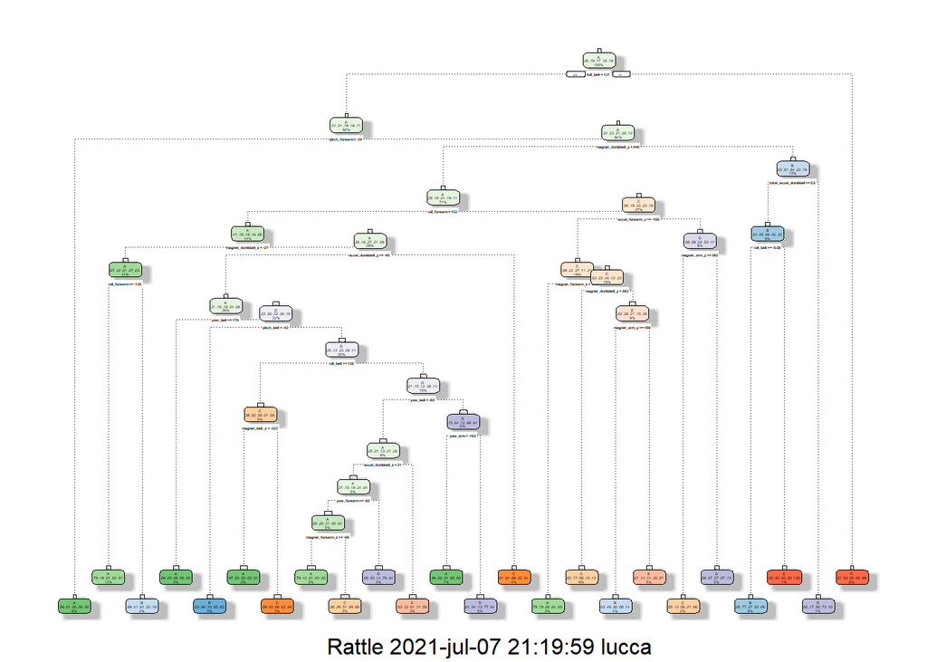

```r
set.seed(1543)
Mod_DT <- rpart(classe ~ ., data=training_final, method="class")
fancyRpartPlot(Mod_DT)
```

```r
Pred_DT <- predict(Mod_DT, testing_final, type = "class")
cmtree <- confusionMatrix(Pred_DT, testing_final$classe)
cmtree
```

```
## Confusion Matrix and Statistics
##
##           Reference
## Prediction    A    B    C    D    E
##          A 1539  157   16   38    7
##          B   61  643  119   84   91
##          C   31  157  792   83   90
##          D   27   74   62  670   78
##          E   16  108   37   89  816
##
## Overall Statistics
##
##                Accuracy : 0.7579
##                  95% CI : (0.7467, 0.7688)
##     No Information Rate : 0.2845
##     P-Value [Acc > NIR] : < 2.2e-16
##
##                   Kappa : 0.6933
##
##  Mcnemar's Test P-Value : 3.891e-14
##
## Statistics by Class:
##
##                      Class: A Class: B Class: C Class: D Class: E
## Sensitivity            0.9194   0.5645   0.7719   0.6950   0.7542
## Specificity            0.9482   0.9252   0.9257   0.9510   0.9479
## Pos Pred Value         0.8759   0.6443   0.6869   0.7355   0.7655
## Neg Pred Value         0.9673   0.8985   0.9505   0.9409   0.9448
## Prevalence             0.2845   0.1935   0.1743   0.1638   0.1839
## Detection Rate         0.2615   0.1093   0.1346   0.1138   0.1387
## Detection Prevalence   0.2986   0.1696   0.1959   0.1548   0.1811
## Balanced Accuracy      0.9338   0.7449   0.8488   0.8230   0.8511
```

##3.2 Random Forest

```r
Con_RF <- trainControl(method="cv", number=3, verboseIter=FALSE)
Mod_RF <- train(classe ~ ., data=training_final, method="rf", trControl=Con_RF, tuneLength = 5)
Mod_RF$finalModel
```

```
##
## Call:
##  randomForest(x = x, y = y, mtry = param$mtry)
##                Type of random forest: classification
##                      Number of trees: 500
## No. of variables tried at each split: 14
##
##         OOB estimate of  error rate: 0.59%
## Confusion matrix:
##      A    B    C    D    E  class.error
## A 3903    3    0    0    0 0.0007680492
## B   15 2637    6    0    0 0.0079006772
## C    0   14 2377    5    0 0.0079298831
## D    0    0   25 2225    2 0.0119893428
## E    0    0    3    8 2514 0.0043564356
```

```r
Pred_RF <- predict(Mod_RF, newdata=testing_final)
cmrf <- confusionMatrix(Pred_RF, testing_final$classe)
cmrf
```

```
## Confusion Matrix and Statistics
##
##           Reference
## Prediction    A    B    C    D    E
##          A 1673    4    0    0    0
##          B    0 1132    5    0    0
##          C    0    3 1021    8    1
##          D    0    0    0  956    6
##          E    1    0    0    0 1075
##
## Overall Statistics
##
##                Accuracy : 0.9952
##                  95% CI : (0.9931, 0.9968)
##     No Information Rate : 0.2845
##     P-Value [Acc > NIR] : < 2.2e-16
##
##                   Kappa : 0.994
##
##  Mcnemar's Test P-Value : NA
##
## Statistics by Class:
##
##                      Class: A Class: B Class: C Class: D Class: E
## Sensitivity            0.9994   0.9939   0.9951   0.9917   0.9935
## Specificity            0.9991   0.9989   0.9975   0.9988   0.9998
## Pos Pred Value         0.9976   0.9956   0.9884   0.9938   0.9991
## Neg Pred Value         0.9998   0.9985   0.9990   0.9984   0.9985
## Prevalence             0.2845   0.1935   0.1743   0.1638   0.1839
## Detection Rate         0.2843   0.1924   0.1735   0.1624   0.1827
## Detection Prevalence   0.2850   0.1932   0.1755   0.1635   0.1828
## Balanced Accuracy      0.9992   0.9964   0.9963   0.9952   0.9967
```

##3.3 Gradient Boosted Trees

```r
Con_GBM <- trainControl(method = "repeatedcv", number = 5, repeats = 1)
Mod_GBM  <- train(classe ~ ., data=training_final, method = "gbm", trControl = Con_GBM, verbose = FALSE)
Mod_GBM$finalModel
```

```
## A gradient boosted model with multinomial loss function.
## 150 iterations were performed.
## There were 52 predictors of which 52 had non-zero influence.
```

```r
Pred_GBM <- predict(Mod_GBM, testing_final)
cmgbm <- confusionMatrix(Pred_GBM, testing_final$classe)
cmgbm
```

```
## Confusion Matrix and Statistics
##
##           Reference
## Prediction    A    B    C    D    E
##          A 1642   35    0    1    3
##          B   25 1064   37    1   14
##          C    2   38  978   34    5
##          D    3    1    9  924   17
##          E    2    1    2    4 1043
##
## Overall Statistics
##
##                Accuracy : 0.9602
##                  95% CI : (0.9549, 0.9651)
##     No Information Rate : 0.2845
##     P-Value [Acc > NIR] : < 2.2e-16
##
##                   Kappa : 0.9497
##
##  Mcnemar's Test P-Value : 1.684e-05
##
## Statistics by Class:
##
##                      Class: A Class: B Class: C Class: D Class: E
## Sensitivity            0.9809   0.9342   0.9532   0.9585   0.9640
## Specificity            0.9907   0.9838   0.9837   0.9939   0.9981
## Pos Pred Value         0.9768   0.9325   0.9253   0.9686   0.9914
## Neg Pred Value         0.9924   0.9842   0.9901   0.9919   0.9919
## Prevalence             0.2845   0.1935   0.1743   0.1638   0.1839
## Detection Rate         0.2790   0.1808   0.1662   0.1570   0.1772
## Detection Prevalence   0.2856   0.1939   0.1796   0.1621   0.1788
## Balanced Accuracy      0.9858   0.9590   0.9685   0.9762   0.9810
```

##3.4 Accuracy Comparison

The accuracy and for each model was:

- Decision Trees - Accuracy 0.757859 and Sample error rate 0.242141
- Random Forest - Accuracy 0.9952421 and Sample error rate 0.0047579
- Gradient Boosted Trees 0.9602379 and Sample error rate 0.0397621

The best model is the Random Forest. This model will be used for the test set.

##4. Test Data

```r
Pred_TestData <- predict(Mod_RF, testing_rawdata)
Pred_TestData
```

```
##  [1] B A B A A E D B A A B C B A E E A B B B
## Levels: A B C D E
```